# Practical Machine Learning Course Project

2022-12-16

## Part I: Feature Selection

### Setup

```r
install.packages("dplyr")
##
## The downloaded binary packages are in
##  /var/folders/r_/__ttzfk12nd72x2r2pqnmgbc0000gn/T//RtmpM7v757/downloaded_packages
library("dplyr")

training_data <- read.csv("pml-training.csv")
testing_data <- read.csv("pml-testing.csv")
dim(training_data)
## [1] 19622   160
#str(training_data)
dim(testing_data)
## [1]  20 160
#str(testing_data)
```

### Data cleanup

#### Remove irrelevant/redundant columns

The column in the dataset named `X` contains the observation number. The `user_name` identifies the person performing the activity, and the `cvtd_timestamp` column contains the date which is likely redundant information given that the raw timestamp is also present in the dataset. Let’s remove these three columns as they are unlikely to be useful predictors.

```r
data <- training_data %>% select(!c("X", "cvtd_timestamp", "user_name"))
```

#### Remove near zero variance columns

Next, let’s remove those columns that have close to zero variance. These have very few unique values so they are also unlikely to be helpful predictors.

```r
predictors_to_remove <- row.names(nearZeroVar(data, saveMetrics = TRUE, names = TRUE) %>% filter(zeroVar == TRUE | nzv == TRUE))
data <- data %>% select(!all_of(predictors_to_remove))
```

#### Remove columns that are mostly (> 95%) NA

Finally, let’s explore the NA values within the dataset.

```r
dim(data)
```

```
## [1] 19622    97
```

```r
na_rowwise <- rowSums(is.na(data[, -97]))
na_percentage_of_rows <- sum(na_rowwise > 0) / nrow(data)
na_percentage_of_rows
```

```
## [1] 0.9793089
```

```r
predictor_na_percentage <- lapply(data[, -97], function(x) {round(sum(is.na(x))/length(x), 2)})
sum(predictor_na_percentage > 0)
```

```
## [1] 41
```

```r
sum(predictor_na_percentage > .95)
```

```
## [1] 41
```

From the output above, 97.93% of all rows in the dataset are affected by NA values. Since such a large percentage of rows is affected, we cannot just drop the rows with NA values. Imputing values may also not be a great idea if this is needed for so many rows. There appear to be 41 columns that contain NA values and for each of these columns, NAs make up most of the data (> 95% of the data in the column is NA). These won’t be very useful predictors, let’s remove them. Once removed, there are no longer any NAs left in the data.

```r
predictor_names <- names(data[, -97])
predictors_to_remove <- Filter(function (x) predictor_na_percentage[[x]] >= 0.95, predictor_names)
data <- data %>% select(!all_of(predictors_to_remove))
sum(is.na(data))
```

```
## [1] 0
```

#### Cleaned up dataset

This leaves us a cleaned up dataset with 55 predictors plus one additional column which is the response.

```r
dim(data)
```

```
## [1] 19622    56
```

```r
str(data)
```

```
## 'data.frame':    19622 obs. of  56 variables:
##  $ raw_timestamp_part_1: int  1323084231 1323084231 1323084231 1323084232 1323084232 1323084232 1323084232 1323084232 1323084232 1323084232 ...
##  $ raw_timestamp_part_2: int  788290 808298 820366 120339 196328 304277 368296 440390 484323 484434 ...
##  $ num_window          : int  11 11 11 12 12 12 12 12 12 12 ...
##  $ roll_belt           : num  1.41 1.41 1.42 1.48 1.48 1.45 1.42 1.42 1.43 1.45 ...
##  $ pitch_belt          : num  8.07 8.07 8.07 8.05 8.07 8.06 8.09 8.13 8.16 8.17 ...
##  $ yaw_belt            : num  -94.4 -94.4 -94.4 -94.4 -94.4 -94.4 -94.4 -94.4 -94.4 -94.4 ...
##  $ total_accel_belt    : int  3 3 3 3 3 3 3 3 3 3 ...
##  $ gyros_belt_x        : num  0 0.02 0 0.02 0.02 0.02 0.02 0.02 0.02 0.03 ...
##  $ gyros_belt_y        : num  0 0 0 0 0.02 0 0 0 0 0 ...
##  $ gyros_belt_z        : num  -0.02 -0.02 -0.02 -0.03 -0.02 -0.02 -0.02 -0.02 -0.02 0 ...
##  $ accel_belt_x        : int  -21 -22 -20 -22 -21 -21 -22 -22 -20 -21 ...
##  $ accel_belt_y        : int  4 4 5 3 2 4 3 4 2 4 ...
##  $ accel_belt_z        : int  22 22 23 21 24 21 21 21 24 22 ...
##  $ magnet_belt_x       : int  -3 -7 -2 -6 -6 0 -4 -2 1 -3 ...
```

[output cut: 42 more lines]

## Part II: Model Selection

### Model Training

The code below sets up the environment for parallel processing. We’re splitting the dataset into the predictor variables and the response variable, but using the entire training data set. We’ll perform k-fold cross validation, which involves partitioning the training dataset into 5 equal grouping and using 4 of these at a time to train the models while using the remaining fold for validation. Performance will be measured across the folds.

We’re going to try two ensemble methods - random forest and boosting - as ensemble methods can build a powerful model from weaker building block models. Since the dataset has a large number of predictors and we are unsure of the importance of each, using a method such as random forest that randomly selects a subset of predictors is a useful way to ensure we pick the right predictors for the model. Boosting on the other hand, might be a good candidate for its slow learning approach over something like bagging, so we’ll also fit a boosted model for comparison.

```r
install.packages(c("caret", "doParallel", "parallel"))
library("caret")
library("doParallel")
library("parallel")

set.seed(36401)

x <- data[,-56]
y <- data[, 56]

# Use `parallel` package instead of `doMC` for cross platform compatability
# register the parallell technology with `foreach` before calling `train`
cluster <- makeCluster(detectCores() - 1) # convention to leave 1 core for OS
registerDoParallel(cluster)

# Instead of the default resampling scheme (bootstrap), let's use 5-fold cross-validation
fitControl <- trainControl(method = "cv", number = 5, allowParallel = TRUE)

# Fit a random forest model
fit_rf <- train(x, y, method = "rf", trControl = fitControl)

# Fit a generalized boosted model
fit_gbm <- train(x, y, method = "gbm", trControl = fitControl)
stopCluster(cluster)
registerDoSEQ()
```

### Model Selection

```r
fit_rf
```

```
## Random Forest
##
## 19622 samples
##    55 predictor
##     5 classes: 'A', 'B', 'C', 'D', 'E'
##
## No pre-processing
## Resampling: Cross-Validated (5 fold)
## Summary of sample sizes: 15697, 15697, 15698, 15699, 15697
## Resampling results across tuning parameters:
##
##   mtry  Accuracy   Kappa
##    2    0.9973500  0.9966480
##   28    0.9991336  0.9989041
##   55    0.9986750  0.9983240
##
## Accuracy was used to select the optimal model using the largest value.
## The final value used for the model was mtry = 28.
```

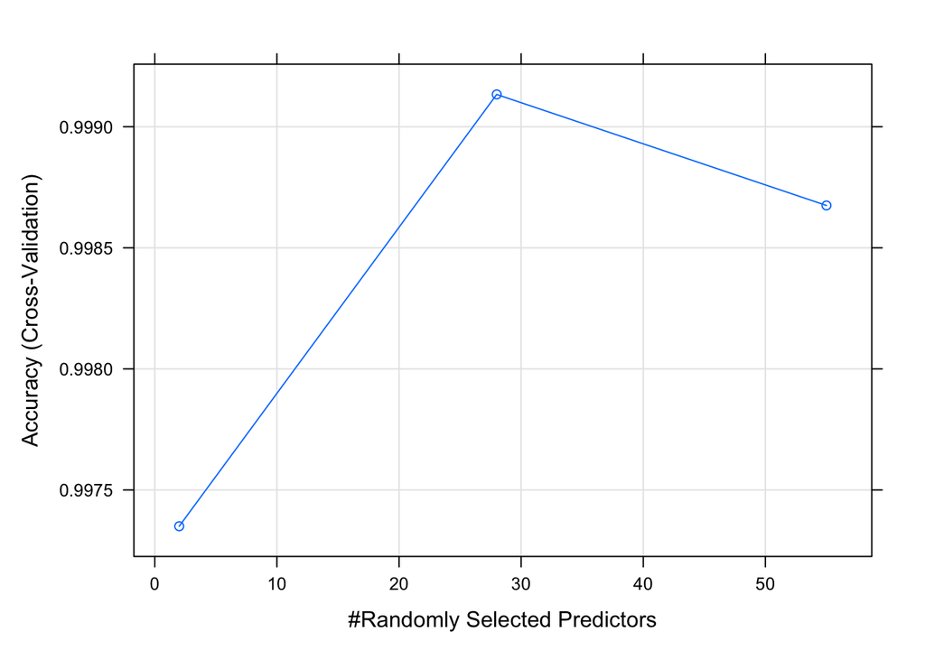

```r
plot.train(fit_rf)
```

```r
confusionMatrix.train(fit_rf)
```

```
## Cross-Validated (5 fold) Confusion Matrix
##
## (entries are percentual average cell counts across resamples)
##
##           Reference
## Prediction    A    B    C    D    E
##          A 28.4  0.0  0.0  0.0  0.0
##          B  0.0 19.3  0.0  0.0  0.0
##          C  0.0  0.0 17.4  0.0  0.0
##          D  0.0  0.0  0.0 16.4  0.0
##          E  0.0  0.0  0.0  0.0 18.4
##
##  Accuracy (average) : 0.9991
```

The boosted model had an accuracy of 0.9964321, thus out-of-bag error rate of 0.0035679.

```r
fit_gbm
```

```
## Stochastic Gradient Boosting
##
## 19622 samples
##    55 predictor
##     5 classes: 'A', 'B', 'C', 'D', 'E'
##
## No pre-processing
## Resampling: Cross-Validated (5 fold)
## Summary of sample sizes: 15696, 15699, 15696, 15698, 15699
## Resampling results across tuning parameters:
##
##   interaction.depth  n.trees  Accuracy   Kappa
##   1                   50      0.8129144  0.7626656
##   1                  100      0.8883393  0.8586168
##   1                  150      0.9162157  0.8939351
##   2                   50      0.9384863  0.9221312
##   2                  100      0.9780851  0.9722731
##   2                  150      0.9913359  0.9890411
##   3                   50      0.9675360  0.9589240
##   3                  100      0.9927625  0.9908460
##   3                  150      0.9964321  0.9954871
##
## Tuning parameter 'shrinkage' was held constant at a value of 0.1
## Tuning parameter 'n.minobsinnode' was held constant at a value of 10
## Accuracy was used to select the optimal model using the largest value.
## The final values used for the model were n.trees = 150, interaction.depth = 3, shrinkage = 0.1 and n.minobsinnode = 10.
```

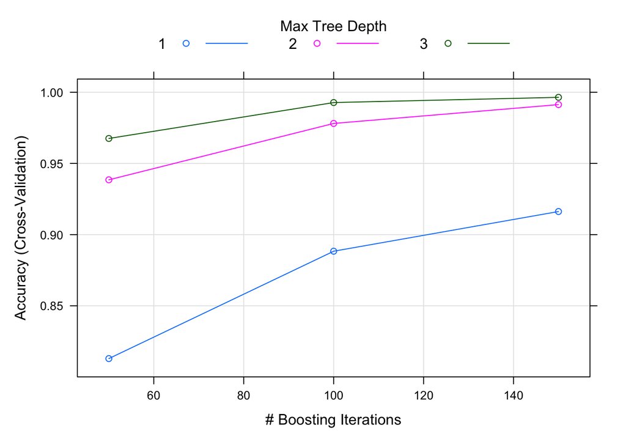

```r
plot.train(fit_gbm)
```

```r
confusionMatrix.train(fit_gbm)
```

```
## Cross-Validated (5 fold) Confusion Matrix
##
## (entries are percentual average cell counts across resamples)
##
##           Reference
## Prediction    A    B    C    D    E
##          A 28.4  0.0  0.0  0.0  0.0
##          B  0.0 19.3  0.0  0.0  0.0
##          C  0.0  0.0 17.3  0.1  0.0
##          D  0.0  0.0  0.1 16.3  0.0
##          E  0.0  0.0  0.0  0.0 18.3
##
##  Accuracy (average) : 0.9964
```

The random forest model performs better than the boosted model, with higher mean accuracy and lower variance across the cross validation resamples, so we will pick it as our model for prediction.

```r
results <- resamples(list(RF=fit_rf, GBM=fit_gbm))
results$values
```

```
##   Resample RF~Accuracy  RF~Kappa GBM~Accuracy GBM~Kappa
## 1    Fold1   0.9994904 0.9993555    0.9971982 0.9964564
## 2    Fold2   0.9987261 0.9983887    0.9936273 0.9919390
## 3    Fold3   0.9989806 0.9987107    0.9984717 0.9980669
## 4    Fold4   0.9989804 0.9987103    0.9969419 0.9961321
## 5    Fold5   0.9994904 0.9993555    0.9959215 0.9948411
```

```r
summary(results)
```

```
##
## Call:
## summary.resamples(object = results)
##
## Models: RF, GBM
## Number of resamples: 5
##
## Accuracy
##          Min.   1st Qu.    Median      Mean   3rd Qu.      Max. NA's
## RF  0.9987261 0.9989804 0.9989806 0.9991336 0.9994904 0.9994904    0
## GBM 0.9936273 0.9959215 0.9969419 0.9964321 0.9971982 0.9984717    0
##
## Kappa
##          Min.   1st Qu.    Median      Mean   3rd Qu.      Max. NA's
## RF  0.9983887 0.9987103 0.9987107 0.9989041 0.9993555 0.9993555    0
## GBM 0.9919390 0.9948411 0.9961321 0.9954871 0.9964564 0.9980669    0
```

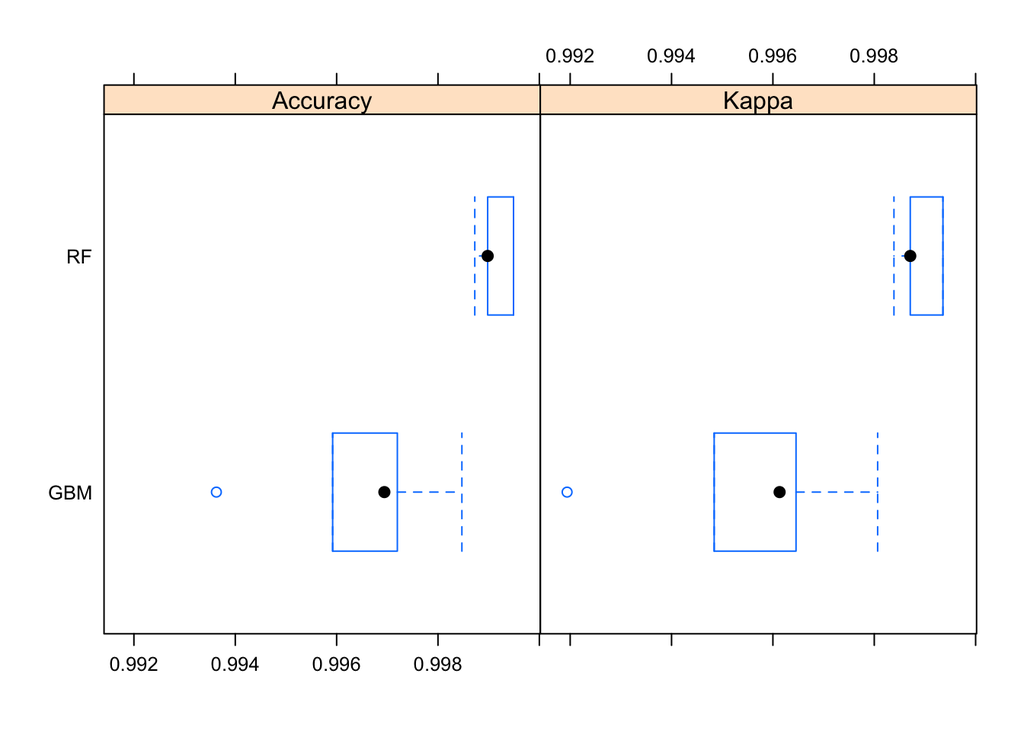

```r
bwplot(results)
```

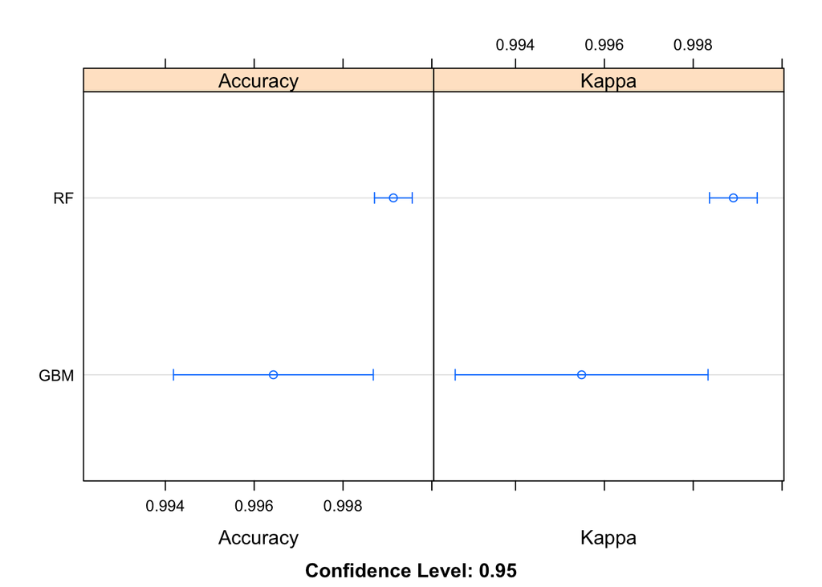

```r
dotplot(results)
```

## Prediction

We now use the trained random forest model to make predictions on the test data

```r
predictor_names <- names(data[, -56])
testing_data <- testing_data %>% select(all_of(predictor_names))
predictions_testing_data_rf <- predict.train(fit_rf, testing_data)
predictions_testing_data_rf
```

```
##  [1] B A B A A E D B A A B C B A E E A B B B
## Levels: A B C D E
```